# **CIV1299: Construction Safety: IoT and AI Solutions**

### Question 1.11 -- [5pt]

Explain the concept of Momentum. What is its range? How would increasing or decreaing it alter the performance of the model? You are recommended to copy and paste the block of code above (from question 1.10) to report the performance of your model with different momentums.

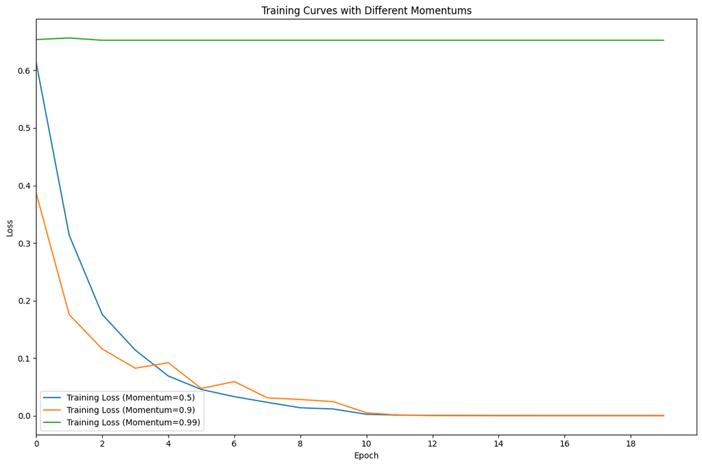

```python
# =================== YOUR ANSWER STARTS HERE ==================

'''
In the context of optimization algorithms, momentum is a technique used to
accelerate the convergence of the optimization process. It is particularly
helpful when dealing with noisy or sparse gradients. The concept of
momentum is inspired by physics, where an object in motion tends to
keep moving in the same direction unless acted upon by an external force.

In the context of Stochastic Gradient Descent (SGD) optimization,
momentum introduces a moving average of the gradients, which helps
the optimization algorithm "build up speed" in the relevant directions.

'''
import matplotlib.pyplot as plt
import torch
import torch.nn as nn
import torch.nn.functional as F
from torchvision import datasets, transforms
import torch.optim as optim
from tqdm import tqdm

# load the data
mnist_data = datasets.MNIST('data', train=True, download=True)
mnist_data = list(mnist_data)
mnist_train = mnist_data[:1000]
mnist_val   = mnist_data[1000:2000]
img_to_tensor = transforms.ToTensor()

# define your custom ANN
class Pigeon3(nn.Module):
    def __init__(self):
        super(Pigeon3, self).__init__()
        # =================== YOUR CODE STARTS HERE ==================
        self.layer1 = nn.Linear(28 * 28, 128)
        self.layer2 = nn.Linear( 128 , 64)
        self.layer3 = nn.Linear( 64 , 32)
        self.layer4 = nn.Linear( 32 , 1)
        # ==================== YOUR CODE ENDS HERE ===================

    def forward(self, img):
        flattened = img.view(-1, 28 * 28)
        activation1 = F.relu(self.layer1(flattened))
        activation2 = F.relu(self.layer2(activation1))
        activation3 = F.relu(self.layer3(activation2))
        activation4 = self.layer4(activation3)
        return activation4

# Test with different momentums
momentums = [0.5, 0.9, 0.99]
results = []

for momentum_value in momentums:
    # Initialize model, criterion, and optimizer
    pigeon3 = Pigeon3()
    criterion = nn.BCEWithLogitsLoss()
    optimizer = optim.SGD(pigeon3.parameters(), lr=0.005, momentum=momentum_value)

    # Training loop with progress bar
    train_losses = []
    for epoch in tqdm(range(num_epochs), desc=f'Training Progress (Momentum={momentum_value})'):
        epoch_loss = 0
        for (image, label) in mnist_train:
            actual = torch.tensor(label < 3).reshape([1, 1]).type(torch.FloatTensor)
            out = pigeon3(img_to_tensor(image))
            loss = criterion(out, actual)
            loss.backward()
            optimizer.step()
            optimizer.zero_grad()
            epoch_loss += loss.item()
        train_losses.append(epoch_loss / len(mnist_train))

    # Computing accuracy on the test set
    train_accuracy = 1 - compute_accuracy(mnist_train)
    test_accuracy = 1 - compute_accuracy(mnist_val)

    results.append({
        'momentum': momentum_value,
        'train_accuracy': train_accuracy,
        'test_accuracy': test_accuracy,
        'train_losses': train_losses,
    })

# Plotting the training curves
plt.figure(figsize=(12, 8))
for result in results:
    plt.plot(range(num_epochs), result['train_losses'], label=f'Training Loss (Momentum={result["momentum"]})')

plt.xlabel('Epoch')
plt.ylabel('Loss')
plt.title('Training Curves with Different Momentums')
plt.legend()
plt.grid(False)
plt.xticks(range(0, num_epochs, 2))
plt.xlim(0, num_epochs)
plt.tight_layout()
plt.show()

# Displaying accuracy results
for result in results:
    print(f"Momentum={result['momentum']}: Train Accuracy={result['train_accuracy']:.4f}, Test Accuracy={result['test_accuracy']:.4f}")



'''



Momentum = 0.5

Train Accuracy: 100.0%
Test Accuracy: 93.6%
Momentum = 0.9

Train Accuracy: 100.0%
Test Accuracy: 95.2%
Momentum = 0.99

Train Accuracy: 68.8%
Test Accuracy: 70.3%

Interpretation:
Momentum 0.5 and 0.9: Both perform well, achieving 100% training accuracy.
A higher test accuracy is observed with momentum 0.9 compared to 0.5.

Momentum 0.99: The model struggles to converge, resulting in lower
accuracy and consistent loss. A high momentum value can lead to slower
convergence or instability.


Momentum values between 0.5 and 0.9 seem effective for this task.
Adjustments to learning rate and hidden layer configurations might
further improve results.



'''


# ==================== YOUR ANSWER ENDS HERE ===================
```

[output not shown]

### Question 1.12 -- [5pt]

Explain the concept of Epoch. How is it different than Iterations during the training? What is the problem of training the model for too many epochs? You are recommnded to copy and paste the block of code from question 1.10 to check the performance of your model with too many epochs. Explain what could go wrong!

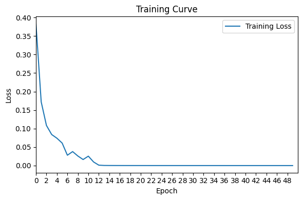

```
Training Accuracy: 1.0
Test Accuracy: 0.946
```

```python
# =================== YOUR ANSWER STARTS HERE ==================

'''
Epoch:
An epoch is a single pass through the entire training dataset during the
training of a neural network.
During one epoch, the model sees and processes every
training example at least once.
After each epoch, the model's parameters are adjusted to improve its
performance on the training data.

Iterations:
An iteration is a single update of the model's parameters,
often involving a batch of input samples.
The number of iterations per epoch depends on the batch size.

Difference:
An epoch is a higher-level concept representing a complete pass
through the entire dataset, while an iteration is a lower-level
concept referring to a single update step.

Training for Too Many Epochs:
Overfitting can occur when a model is trained for too many epochs.
The model becomes highly specialized to the training set and may perform
poorly on new, unseen data.
Training for too many epochs may also waste computational resources without
significant improvement in performance.

Monitoring performance on a validation set during training and stopping
when performance plateaus or starts degrading can help prevent overfitting.
Techniques like early stopping or model checkpoints can be employed to
save the best-performing model during training.

'''

# load the data
mnist_data = datasets.MNIST('data', train=True, download=True)
mnist_data = list(mnist_data)
mnist_train = mnist_data[:1000]
mnist_val   = mnist_data[1000:2000]
img_to_tensor = transforms.ToTensor()

pigeon3 = Pigeon3()

# Training settings
criterion = nn.BCEWithLogitsLoss()
optimizer = optim.SGD(pigeon3.parameters(), lr=0.005, momentum=0.9)
num_epochs = 50  # Number of training epochs

# Training loop with progress bar
train_losses = []
for epoch in tqdm(range(num_epochs), desc='Training Progress'):
    epoch_loss = 0
    for (image, label) in mnist_train:
        actual = torch.tensor(label < 3).reshape([1, 1]).type(torch.FloatTensor)
        out = pigeon3(img_to_tensor(image))
        loss = criterion(out, actual)
        loss.backward()
        optimizer.step()
        optimizer.zero_grad()
        epoch_loss += loss.item()
    train_losses.append(epoch_loss / len(mnist_train))

# Plotting the training curve
plt.figure(figsize=(6, 4))
plt.plot(range(num_epochs), train_losses, label='Training Loss')
plt.xlabel('Epoch')
plt.ylabel('Loss')
plt.title('Training Curve')
plt.legend()
plt.grid(False)
plt.xticks(range(0,num_epochs, 2))  # Integer values for epochs on X axis
plt.xlim(0, num_epochs)  # Set the x-axis limits
plt.tight_layout()
plt.show()

train_accuracy = 1 - compute_accuracy(mnist_train)
test_accuracy = 1 - compute_accuracy(mnist_val)

print("Training Accuracy:", train_accuracy)
print("Test Accuracy:", test_accuracy)


'''

Explain what could go wrong!

Overfitting: Training for too many epochs might lead to overfitting,
where the model becomes too specialized in the training data and fails to
generalize well to new, unseen data. This is evident if you observe that the
training loss continues to decrease while the test
accuracy plateaus or decreases.

Training for too many epochs increases the computational cost.
If your model has already reached optimal performance, further training may
not bring substantial benefits but will consume additional
computational resources.


'''

# ==================== YOUR ANSWER ENDS HERE ===================
```

### Question 1.13 -- [5pt]

Describe the impact of different activation functions (e.g. ReLU, Sigmoid, Tanh) on the performance of the model. How would you go about choosing the appropriate activation function for simpleANN? Feel free to provide code!

```python
# =================== YOUR ANSWER STARTS HERE ==================

'''


Activation functions play a crucial role in shaping the output and influencing
the learning dynamics of neural networks.

ReLU:
ReLU is widely used in hidden layers due to its simplicity and effectiveness.
It allows positive values to pass through, promoting sparse activations
and faster convergence during training.
However, ReLU can suffer from the "dying ReLU" problem, where neurons may
become inactive and stop learning if they always output zero during training.

Sigmoid:
Sigmoid is commonly used in the output layer for binary classification problems.
It squashes the output between 0 and 1, interpreting it as probabilities.
Sigmoid can cause vanishing gradient problems during backpropagation
impacting the training of deep networks.

Tanh:
Tanh addresses the zero-centering issue of ReLU by squashing the output
between -1 and 1. It is useful when data distribution is centered around zero.
Similar to sigmoid, tanh may suffer from vanishing gradient problems
especially in deep networks.

ReLU is a default choice for hidden layers.
Sigmoid is suitable for binary classification, while softmax is used for
multi-class problems. Tanh is an alternative when zero-centering is essential.

The choice may depend on empirical testing, and different layers within
the same network can have different activation functions.

Example Code:

class SimpleANN(nn.Module):
    def __init__(self):
        super(SimpleANN, self).__init__()
        self.layer1 = nn.Linear(input_size, hidden_size)
        self.layer2 = nn.Linear(hidden_size, output_size)

    def forward(self, x):
        x = F.relu(self.layer1(x))
        x = self.layer2(x)
        return x

'''


# ==================== YOUR ANSWER ENDS HERE ===================
```